[figure not shown]

## 12th of April, 2018, Lund University

The conference is over and we would like to thank everybody that participated and made this such great event! Below in the Schedule you’ll now find the slides and video recordings from all the presentations.

Good Bayes!  
/The Organisers  
*Rasmus Bååth* (rasmus.baath@gmail.com)  
*Ullrika Sahlin* (ullrika.sahlin@cec.lu.se)

[figure not shown]

## Schedule + videos and slides from the talks

[output not shown]

## Program

For the full program, including abstracts, see [the program booklet](https://rawgit.com/bayesat/bayesat.github.io/master/lund2018/bayes_at_lund_2018_program.pdf):

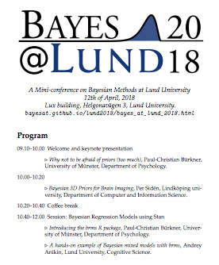

## Introduction

You are welcome to participate in the fifth edition of Bayes@Lund! The purpose of this conference is to bring together researchers and professionals working with or interested in Bayesian methods. Bayes@Lund aims at being **accessible** to researchers with little experience of Bayesian methods while still being **relevant** to experienced practitioners. The focus is on how Bayesian methods are used in research and in the industry, what advantages Bayesian methods have over classical alternatives, and how the use and teaching of Bayesian methods can be encouraged.

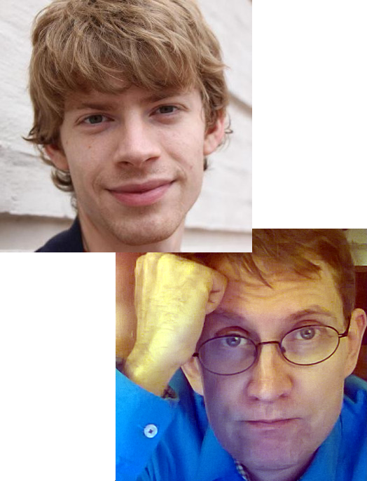

This conference will feature a number of contributed talks and short tutorials, and invited talks by [Paul-Christian Bürkner](https://paul-buerkner.github.io/) and [Jukka Ranta](https://www.evira.fi/en/about-evira/contact/personnel-search/r/jukka-ranta/).

#### Invited speakers: Paul-Christian Bürkner and Jukka Ranta

This year we are happy to announce that the first invited speaker is [Paul-Christian Bürkner](https://paul-buerkner.github.io/), researcher at the University of Münster, Department of Psychology. Paul is an expert in Bayesian statistical modeling, and is the creator of the well-known [BRMS software package](https://www.jstatsoft.org/article/view/v080i01) that makes it easy to do advanced Bayesian modeling. His invited presentation is *Why not to be afraid of priors (too much)*.

We are equally happy to announce that the second invited speaker is [Jukka Ranta](https://www.evira.fi/en/about-evira/contact/personnel-search/r/jukka-ranta/), professor at the Finnish Food Safety Authority, and docent of biometry from Helsinki University. Jukka’s research is focused on Bayesian modeling for quantitative risk assessment in food safety applications. His invited presentation is *I know what you ate last summer! – the virtue of Bayesian analysis in food risk assessment*.

## Contact

For more info, contact:

- *Rasmus Bååth*, Lund University Cognitive Science and King Digital Entertainment: rasmus.baath@gmail.com
- *Ullrika Sahlin*, Lund University Centre of Environmental and Climate Research: ullrika.sahlin@cec.lu.se

## Acknowledgement

We are deeply grateful to the [COMPUTE research school](http://cbbp.thep.lu.se/compute/index.php) for financial support of this event. We would like to thank the graduate research school [ClimBEco](https://www.cec.lu.se/education/post-graduate-studies/climbeco-graduate-research-school/about-climbeco) for helping us bring the invited speakers to Lund University. We would also like to thank [King Digital Entertainment](https://king.com/jobs) for sponsoring the program.

[figure not shown]

[figure not shown]